# Atividade Econometria - Experimento na Agroindústria

# Introdução

Um engenheiro está interessado em investigar a resistência de uma nova fibra sintética usada na produção de camisas. Sabendo que a resistência é afetada pela quantidade de algodão usada na fibra, e que a quantidade desejada de algodão no produto final deve estar no intervalo de 10 a 40%,o engenheiro planeja um experimento com as seguintes quantidades de algodão: 15, 20, 25, 30 e 35%, e cinco repetições.

```r
rm(list=ls(all=TRUE))
require(lattice)
require(dae)
require(ExpDes.pt)
library(rmarkdown)

y<- c(7,  7,  15, 11, 9,
      12, 17, 12, 18, 18,
      14, 18, 18, 19, 19,
      19, 25, 22, 19, 23,
      7,  10, 11, 15, 11);

n<- length(y);
i<- 5 # numero de níveis do fator
r<- 5 # numero de repetições

algodao <- factor(rep(c(1:i), each=r), labels=c("15","20","25","30","35"));
repeticoes<- factor(rep(c("1","2","3","4","5"),each=1));

DIC<- data.frame(algodao,repeticoes,y)
attach(DIC)
paged_table(DIC)
```

| algodao | repeticoes | y |
| --- | --- | --- |
| 15 | 1 | 7 |
| 15 | 2 | 7 |
| 15 | 3 | 15 |
| 15 | 4 | 11 |
| 15 | 5 | 9 |
| 20 | 1 | 12 |
| 20 | 2 | 17 |
| 20 | 3 | 12 |
| 20 | 4 | 18 |
| 20 | 5 | 18 |

[output cut: 15 more lines]

## Objetivos

- Avaliar o efeito da porcentagem de algodão na resistência da fibra sintética;
- Identificar a porcentagem ideal de algodão de forma a se obter máxima resistência com menor custo do produto final.

# Metodologia

Para a análise dos dados será utilizado um Delineamento Inteiramente Casualizado (DIC),com auxílio do pacote `ExpDes.pt`para obtensão dos resultados e o pacote `lattice`para a visualização do dados.

# Visualização do experimento

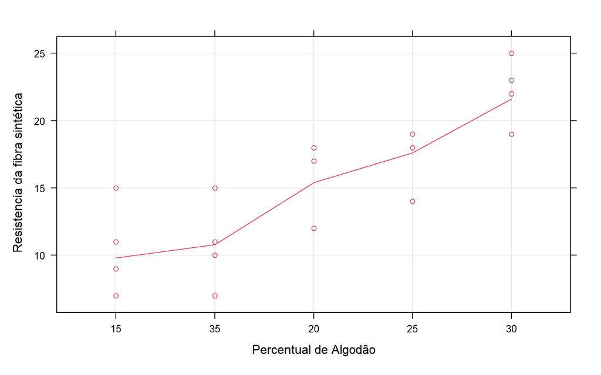

```r
xyplot(y ~ reorder(algodao, y),
       data = DIC,
       type = c("p","g", "a"),
       ylab = expression("Resistencia da fibra sintética"),
       xlab = expression("Percentual de Algodão"),col= 2)
```

## Definindo o modelo de regressão

```r
modelo <- lm(y ~ algodao, DIC)
```

# Análise gráfica do modelo

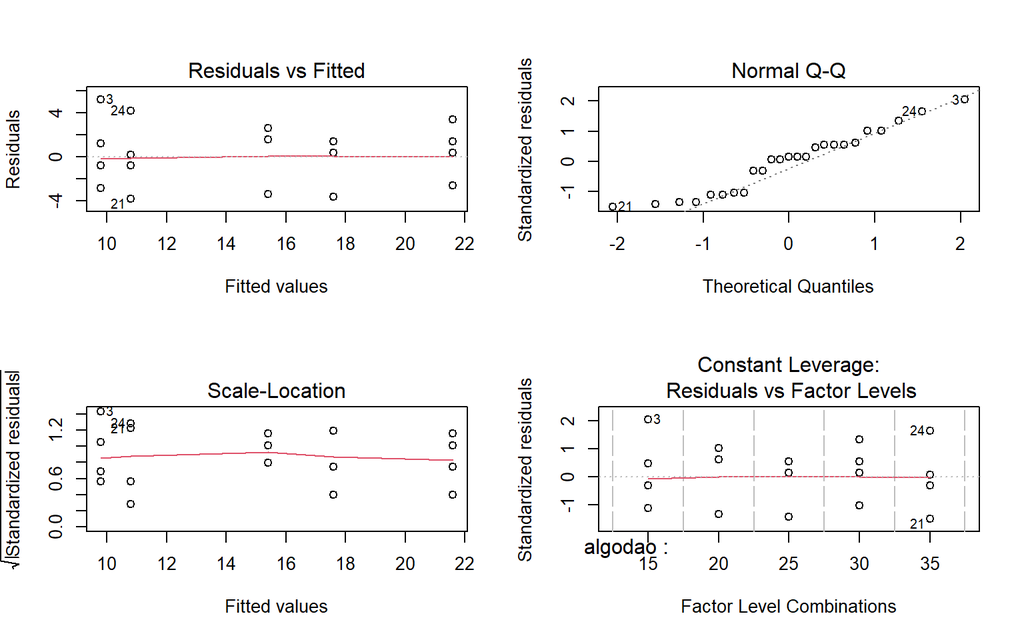

```r
par(mfrow=c(2,2))

plot(modelo)
```

```r
par(mfrow=c(1,1))
```

O primeiro gráfico (superior a esquerda), indica se os resíduos seguem linearidade. Podemos observar que a linha vermelha está bem próxima à linha pontilhada indicando que os resíduos têm linearidade. No segundo gráfico verificamos se os resíduos possuem distribuição normal,neste caso vemos que os resíduos estão bem próximos à linha indicando que há indícios de uma distribuição normal.

# Execussão dos testes

## Hipóteses que iremos testar:

- H0: os níveis de porcentagem de algodão possuem efeitos semelhantes na resistência da fibra sintética.
- H1: os níveis de porcentagem de algodão possuem efeitos diferentes na resistência da fibra sintética.

## Análise de variância e teste Tukey

```r
dic(algodao, y)
```

```
## ------------------------------------------------------------------------
## Quadro da analise de variancia
## ------------------------------------------------------------------------
##            GL     SQ     QM     Fc      Pr>Fc
## Tratamento  4 475.76 118.94 14.757 9.1279e-06
## Residuo    20 161.20   8.06
## Total      24 636.96
## ------------------------------------------------------------------------
## CV = 18.88 %
##
## ------------------------------------------------------------------------
## Teste de normalidade dos residuos ( Shapiro-Wilk )
## Valor-p:  0.1817575
## De acordo com o teste de Shapiro-Wilk a 5% de significancia, os residuos podem ser considerados normais.
## ------------------------------------------------------------------------
##
## ------------------------------------------------------------------------
## Teste de homogeneidade de variancia
## valor-p:  0.9197662
## De acordo com o teste de bartlett a 5% de significancia, as variancias podem ser consideradas homogeneas.
## ------------------------------------------------------------------------
##
## Teste de Tukey
## ------------------------------------------------------------------------
## Grupos Tratamentos Medias
## a     30      21.6
## ab    25      17.6
##  bc   20      15.4
##   cd      35      10.8
##    d      15      9.8
## ------------------------------------------------------------------------
```

Vemos que pela análise de variância o p-valor foi menor que 0,05 então rejeitamos H0, assim podemos concluir que pelo menos um dos níveis de porcentagem de algodão possui efeito na resistência da fibra sintética. Verificamos que os resíduos seguem uma distribuição normal pelo teste de Shapiro-Wilk e as variâncias possuem homogeneidade pelo teste de bartlett. Pelo teste Tukey a porcentagem de algodão com melhor desempenho é de 30%, seguida de 25%. Podemos concluir que acordo com o custo do algodão a porcentagem ideal de forma a se obtenha máxima resistência com menor custo do produto final é de 25%.